# scRNA-seq analysis via Dimensionality reduction

### Technical comments

Try executing a chunk by clicking the *Run* button within the chunk or by placing your cursor inside it and pressing *Cmd+Shift+Enter*. You can also run the next chunk of code via *Cmd+Alt+`*. (These commands are valid on Mac, might differ on Windows)

# Loading libraries

In R (and many other programming language) reusable code written by others is distributed via libraries. In order to use those pieces of code, we first need to install the packages (this has been done previously for all users, as it takes 2+ hours to install all required packages), then we need to load them within our current session.

```r
# Load libraries
library(magrittr) # Pipe %>% operation for clean coding
library(SingleCellExperiment) # Data container (https://bioconductor.org/packages/release/bioc/vignettes/SingleCellExperiment/inst/doc/intro.html)
library(pcaMethods) # Linear DimRed methods (PCA and extensions)
library(RDRToolbox) # Non-linear DimRed methods (LLE, Isomap)
library(ggbiplot)
library(plotly)
library(sparsepca)
library(scran) # scRNA-seq methods, By Aaron Lun, Cambridge researcher
library(tidyverse)
library(printr)
cat("Libraries successfully loaded\n")
```

```
Libraries successfully loaded
```

# Reading and understanding the data

```r
# Read the data
data_zeisel <- readRDS("zeisel.rds")
# Get basic information of the data
print(data_zeisel)
```

```
class: SingleCellExperiment
dim: 19972 3005
metadata(0):
assays(2): counts logcounts
rownames(19972): Tspan12 Tshz1 ... Gm21943_loc3 Gm20738_loc3
rowData names(10): feature_symbol is_feature_control ... total_counts
  log10_total_counts
colnames(3005): X1 X1.1 ... X9.58 X9.59
colData names(30): clust_id cell_type1 ... pct_counts_ERCC is_cell_control
reducedDimNames(0):
spikeNames(1): ERCC
```

```r
# Gene statistics
print(as_tibble(rowData(data_zeisel), rownames="gene_id"))
```

| gene_id | feature_symbol | is_feature_control | is_feature_control_ERCC | mean_counts | log10_mean_counts | rank_counts | n_cells_counts | pct_dropout_counts | total_counts | log10_total_counts |
| --- | --- | --- | --- | --- | --- | --- | --- | --- | --- | --- |
| Tspan12 | Tspan12 | FALSE | FALSE | 0.278868552 | 0.106825908 | 12252.0 | 472 | 84.292845 | 838 | 2.923762 |
| Tshz1 | Tshz1 | FALSE | FALSE | 0.423627288 | 0.153396304 | 13825.0 | 573 | 80.931780 | 1273 | 3.105169 |
| Fnbp1l | Fnbp1l | FALSE | FALSE | 1.042928453 | 0.310253157 | 17040.0 | 1167 | 61.164725 | 3134 | 3.496238 |
| Adamts15 | Adamts15 | FALSE | FALSE | 0.044592346 | 0.018946839 | 7632.5 | 77 | 97.437604 | 134 | 2.130334 |
| Cldn12 | Cldn12 | FALSE | FALSE | 0.379367720 | 0.139680059 | 13410.0 | 669 | 77.737105 | 1140 | 3.057286 |
| Rxfp1 | Rxfp1 | FALSE | FALSE | 0.055906822 | 0.023625596 | 8062.0 | 104 | 96.539101 | 168 | 2.227887 |
| 2310042E22Rik | 2310042E22Rik | FALSE | FALSE | 0.105158070 | 0.043424399 | 9405.0 | 114 | 96.206323 | 316 | 2.501059 |
| Sema3c | Sema3c | FALSE | FALSE | 1.063893511 | 0.314687286 | 17104.5 | 577 | 80.798669 | 3197 | 3.504878 |
| Jam2 | Jam2 | FALSE | FALSE | 0.273544093 | 0.105013986 | 12189.0 | 418 | 86.089850 | 822 | 2.915400 |
| Apbb1ip | Apbb1ip | FALSE | FALSE | 0.053910150 | 0.022803587 | 7986.0 | 99 | 96.705491 | 162 | 2.212188 |

[output cut: 990 more lines]

```r
# Cell statistics
print(as_tibble(colData(data_zeisel), rownames="cell_id"))
```

| cell_id | clust_id | cell_type1 | total_features | log10_total_features | total_counts | log10_total_counts | pct_counts_top_50_features | pct_counts_top_100_features | pct_counts_top_200_features | pct_counts_top_500_features | total_features_endogenous | log10_total_features_endogenous | total_counts_endogenous | log10_total_counts_endogenous | pct_counts_endogenous | pct_counts_top_50_features_endogenous | pct_counts_top_100_features_endogenous | pct_counts_top_200_features_endogenous | pct_counts_top_500_features_endogenous | total_features_feature_control | log10_total_features_feature_control | total_counts_feature_control | log10_total_counts_feature_control | pct_counts_feature_control | total_features_ERCC | log10_total_features_ERCC | total_counts_ERCC | log10_total_counts_ERCC | pct_counts_ERCC | … |
| --- | --- | --- | --- | --- | --- | --- | --- | --- | --- | --- | --- | --- | --- | --- | --- | --- | --- | --- | --- | --- | --- | --- | --- | --- | --- | --- | --- | --- | --- | --- |
| X1 | 1 | interneurons | 4848 | 3.685652 | 21580 | 4.334072 | 19.81928 | 25.94995 | 34.14736 | 48.53568 | 4848 | 3.685652 | 21580 | 4.334072 | 100 | 19.81928 | 25.94995 | 34.14736 | 48.53568 | 0 | 0 | 0 | 0 | 0 | 0 | 0 | 0 | 0 | 0 | … |
| X1.1 | 1 | interneurons | 4685 | 3.670802 | 21748 | 4.337439 | 19.29373 | 26.01159 | 34.71584 | 50.45521 | 4685 | 3.670802 | 21748 | 4.337439 | 100 | 19.29373 | 26.01159 | 34.71584 | 50.45521 | 0 | 0 | 0 | 0 | 0 | 0 | 0 | 0 | 0 | 0 | … |
| X1.2 | 1 | interneurons | 6028 | 3.780245 | 31642 | 4.500278 | 17.42305 | 23.48777 | 31.36970 | 45.97055 | 6028 | 3.780245 | 31642 | 4.500278 | 100 | 17.42305 | 23.48777 | 31.36970 | 45.97055 | 0 | 0 | 0 | 0 | 0 | 0 | 0 | 0 | 0 | 0 | … |
| X1.3 | 1 | interneurons | 5824 | 3.765296 | 32914 | 4.517394 | 19.59349 | 26.12262 | 34.68737 | 49.22222 | 5824 | 3.765296 | 32914 | 4.517394 | 100 | 19.59349 | 26.12262 | 34.68737 | 49.22222 | 0 | 0 | 0 | 0 | 0 | 0 | 0 | 0 | 0 | 0 | … |
| X1.4 | 1 | interneurons | 4701 | 3.672283 | 21530 | 4.333064 | 15.39712 | 21.63493 | 30.38086 | 46.33999 | 4701 | 3.672283 | 21530 | 4.333064 | 100 | 15.39712 | 21.63493 | 30.38086 | 46.33999 | 0 | 0 | 0 | 0 | 0 | 0 | 0 | 0 | 0 | 0 | … |
| X1.5 | 1 | interneurons | 5408 | 3.733117 | 24797 | 4.394417 | 16.50603 | 22.83744 | 31.27394 | 46.43304 | 5408 | 3.733117 | 24797 | 4.394417 | 100 | 16.50603 | 22.83744 | 31.27394 | 46.43304 | 0 | 0 | 0 | 0 | 0 | 0 | 0 | 0 | 0 | 0 | … |
| X1.6 | 1 | interneurons | 6244 | 3.795532 | 31405 | 4.497013 | 17.07053 | 23.38163 | 31.35170 | 45.36539 | 6244 | 3.795532 | 31405 | 4.497013 | 100 | 17.07053 | 23.38163 | 31.35170 | 45.36539 | 0 | 0 | 0 | 0 | 0 | 0 | 0 | 0 | 0 | 0 | … |
| X1.7 | 1 | interneurons | 5734 | 3.758533 | 20385 | 4.309332 | 13.13711 | 19.18568 | 27.48590 | 42.00638 | 5734 | 3.758533 | 20385 | 4.309332 | 100 | 13.13711 | 19.18568 | 27.48590 | 42.00638 | 0 | 0 | 0 | 0 | 0 | 0 | 0 | 0 | 0 | 0 | … |
| X1.8 | 1 | interneurons | 5259 | 3.720986 | 23021 | 4.362143 | 14.51718 | 20.92003 | 29.23852 | 44.93289 | 5259 | 3.720986 | 23021 | 4.362143 | 100 | 14.51718 | 20.92003 | 29.23852 | 44.93289 | 0 | 0 | 0 | 0 | 0 | 0 | 0 | 0 | 0 | 0 | … |
| X1.9 | 1 | interneurons | 5503 | 3.740678 | 24183 | 4.383528 | 15.00227 | 21.59368 | 30.36431 | 45.39553 | 5503 | 3.740678 | 24183 | 4.383528 | 100 | 15.00227 | 21.59368 | 30.36431 | 45.39553 | 0 | 0 | 0 | 0 | 0 | 0 | 0 | 0 | 0 | 0 | … |

[output cut: 990 more lines]

# Reducing dimensionality of the data

#### Step 1 - Remove uninformative genes

The easiest way to reduce the amount of our data is to select only a subset of the recorded genes to analyse.

Before we remove anything, we want to know in the end, how much information we are removing from the data by the subsetting of genes. To do this, we should first know, how much information is in the data. An easy proxy of “information” that we’ll use today is the amount of Variance in the data.

```r
# In order to compute sample-wise variance, we need to center the data
# (Column-wise, so basically find the mean of all data and substract that from each data point to serve as the new origin)
center_colmeans <- function(X) {
    Xmean = colMeans(X)
    X - rep(Xmean, rep.int(nrow(X), ncol(X)))
}
# Get total variance as the trace of the covariance matrix (but to save computation, we can rotate elements in trace as Tr[X X^T] = Tr[X^T X], then realise that this is just = sum(colSums(Xc^2)) )
get_total_matrix_variance <- function(X){
  Xc <- center_colmeans(X)
  sum(colSums(Xc^2))
}
# Write a convenience function that directly computes the variance in our SCE data
get_total_data_variance <- function(sce_data, logcount = TRUE){
  if (logcount){
    sce_data %>%
      logcounts() %>%
      get_total_matrix_variance() ->
      out
  } else {
    sce_data %>%
      counts() %>%
      get_total_matrix_variance() ->
      out
  }

  # Return out
  out
}
# Get total variance in the (log counts) data
total_logcounts_variance <- get_total_data_variance(data_zeisel)
sprintf(paste0(
  "The total variance in the logcounts data is ",
  get_total_data_variance(data_zeisel)
  ))
```

```
[1] "The total variance in the logcounts data is 36490381.8458941"
```

We may then remove genes that have very low total counts in the data:

```r
# We first just remove the genes that have to small total counts across the whole dataset.
min_total_count_per_gene = 25
data_zeisel %>%
  counts() %>%
  rowSums() ->
  tmp_gene_total_counts

data_zeisel[
  tmp_gene_total_counts >= min_total_count_per_gene,
] ->
  data_zeisel_lowcount

# Of course let's check how much information we still have:
sprintf(paste0(
  "After removing low count genes, we retain ",
  format(
    get_total_data_variance(data_zeisel_lowcount) / total_logcounts_variance *100,
    digits=3
  ),
  "%% of the variance."
  ))
```

```
[1] "After removing low count genes, we retain 94.5% of the variance."
```

```r
sprintf(paste0(
  "We now have ", nrow(data_zeisel_lowcount), " / ", nrow(data_zeisel), " genes remain"
  ))
```

```
[1] "We now have 15251 / 19972 genes remain"
```

Next we check from the remaining genes, which one on average have the most variation in fold-changes across the different cells. As our scientific goal currently is to find a way to characterise how cells differ from one-another, this is a reasonable thing to do.

```r
how_many_genes_to_keep = 500
# Next we check from the remaining genes, which one on average have the most fold_changes
data_zeisel_lowcount %>%
  logcounts() %>%  # logcounts assay
  rowVars ->
  gene_count_variances # save row-wise variances
# Add back the names (unfortunately rowVars deletets them)
names(gene_count_variances) <- rownames(data_zeisel_lowcount)

# Do the subsetting based on top N variances (by sorted gene name)
data_zeisel_lowcount[
  names((gene_count_variances %>% sort(decreasing = TRUE))[1:how_many_genes_to_keep]),
  ] ->
  data_zeisel_topgenes
# Of course let's check how much information we still have:
sprintf(paste0(
  "After keeping only the top ", how_many_genes_to_keep, " genes, we retain ",
  format(
    get_total_data_variance(data_zeisel_topgenes) / total_logcounts_variance *100,
    digits=3
  ),
  "%% of the variance."
  ))
```

```
[1] "After keeping only the top 500 genes, we retain 12.1% of the variance."
```

Now we may wish to do some more advanced dimensionality reduction, that takes into account not just properties of single genes, but also how they interact. Principal Component Analysis (PCA) is one such methods, it attempts to reduce the dimensionality of the data not just by getting rid of single genes, but by finding linear combinations of gene expression patterns that are informative, and keep most of the variance intact.

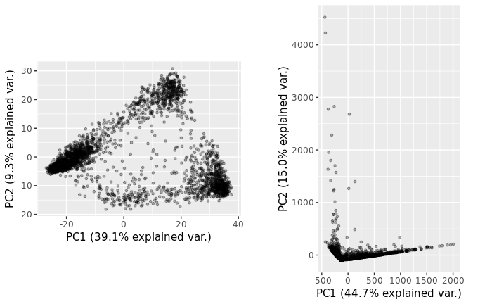